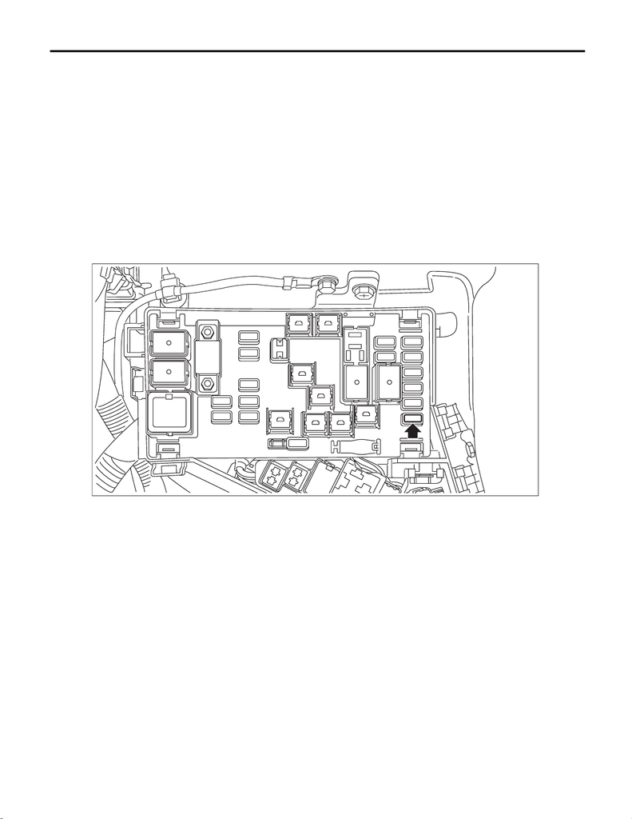

ME(w/o STI)-23

Compression

MECHANICAL

2. Compression

A: INSPECTION

CAUTION:

After warming-up, engine becomes very hot. Be careful not to burn yourself during measurement.

NOTE:

• Before checking the compression pressure, the compression condition of each cylinder can be confirmed

• In the compression measurement mode, the compression condition is judged by each cylinder speed. The

high speed cylinder has low compression pressure and low speed cylinder has high compression pressure.

1) After warming-up the engine, turn the ignition switch to OFF.

2) Make sure that the battery is fully charged.

3) Check the starter motor for satisfactory performance and operation.

4) Remove the fuse of fuel pump from main fuse box.

5) Start the engine and run it until it stalls.

6) After the engine stalls, crank it for five more seconds.

7) Turn the ignition switch to OFF.

8) Remove all spark plugs. <Ref. to IG(w/o STI)-4, REMOVAL, Spark Plug.>

ME-07318

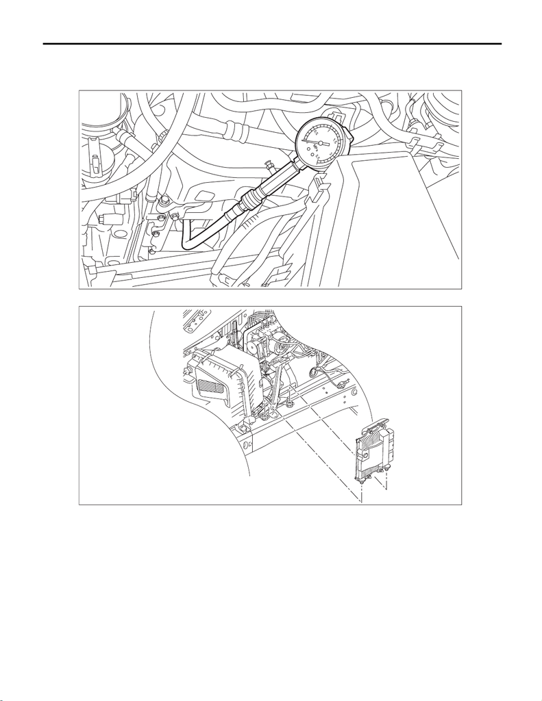

ME(w/o STI)-24

Compression

MECHANICAL

9) Install the compression gauge to the spark plug hole.

NOTE:

When using a screw-in type compression gauge, the screw should be less than 25 mm (0.98 in) long.

ME-07897

FU-08492

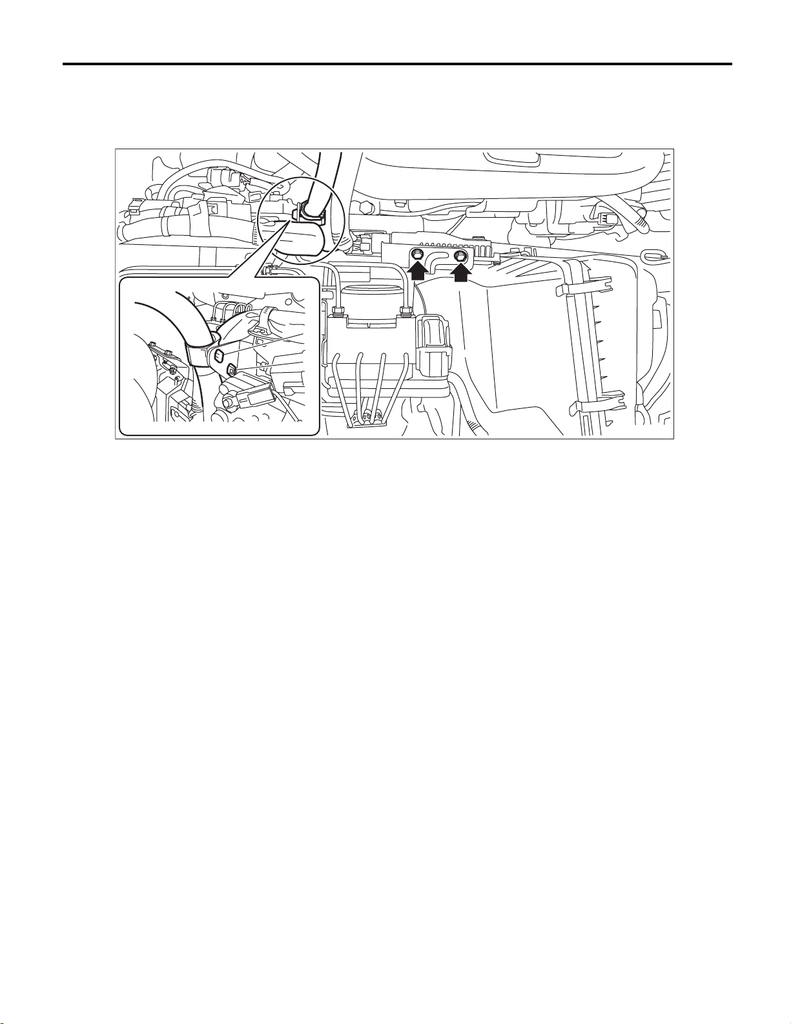

ME(w/o STI)-25

Compression

MECHANICAL

Tightening torque:

7.5 N·m (0.8 kgf-m, 5.5 ft-lb)

12) Install the battery. <Ref. to SC(w/o STI)-50, INSTALLATION, Battery.>

13) Turn the ignition switch to ON.

14) Depress the accelerator pedal to full throttle.

NOTE:

• Perform at least two measurements per cylinder, and make sure that the values are correct.

• If the compression pressure is out of standard, check or adjust the pistons, valves and cylinders.

Compression (fully open throttle):

Standard

Difference between cylinders

16) After inspection, install the related parts in the reverse order of removal.

NOTE:

When compression pressure is checked, the malfunction indicator light illuminates and DTC (P0087) may be

stored in ECM. When the malfunction indicator light has illuminated, perform the Clear Memory Mode. <Ref.

to EN(w/o STI)(diag)-61, Clear Memory Mode.>

IN-03579

(B)

(A)